# ‘dils’: Data-Informed Link Strength

Combine multiple-relationship networks into a single weighted network and impute (fill-in) missing network links

Joshua Cook

10/4/2019

[figure not shown]

This package does not have detailed documentation nor vignettes, so I will just be playing around with it here. The following is the provided description of the package:

> Combine multiple-relationship networks into a single weighted network. The approach is similar to factor analysis in the that contribution from each constituent network varies so as to maximize the information gleaned from the multiple-relationship networks. This implementation uses Principal Component Analysis calculated using ‘prcomp’ with bootstrap subsampling. Missing links are imputed using the method of [Chen *et al.* (2012)](https://clgiles.ist.psu.edu/pubs/SAC2012-discovering-missing-links.pdf).

In the PDF doc, the author provides the following informartion on using the package:

> Start with a table (data.frame, tab-delimited file, database) where each row/record represents a link between two nodes (a dyad) in a directed or undirected network and each column represents a different relationship between the two nodes, ie. each column is a network. DILS combines these columns/networks into a single network that is a weighted sum of the constituent networks. The resulting DILS network uses information from all of the constituent networks and contains more information than any of the constituent networks. The output is a data.frame of DILS scores for each dyad, therefore is a single network ready for analysis using igraph or other social network analysis (SNA) tools.

The following is the suggested workflow for combining the information from multiple graphs:

1. Start with several networks in `igraph`, adjacency list, or edgelist form.
2. Is necessary, use `EdgelistFromIgraph` or `EdgelistFromAdjacency` to convert `igraph` and adjacency list networks to edgelist form.
3. Use `MergeEdgelists` to combine the individual network datasets into a single dataset.
4. Use `GenerateDilsNetwork` to synthesize the networks in the merged data set into a single weighted network.
5. Use `IgraphFromEdgelist` or `AdjacencyFromEdgelist` to convert the edgelist output to the desired output.
6. `UseRelativeNetworkInformation` on input networks and DILS network to see if/how much the information content of the DILS network exceeds the information content of the input networks.

The following is a suggested workflow for imputing edges of a graph:

1. Start with a binary network as an adjacency matrix (for an `igraph` use `get.adjacency()`).
2. Use `RelationStrengthSimilarity` to calculate RSS scores for each dyad.
3. Use `RssSuggestedNetwork` on the original network and the `RelationStrengthSimilarity` output to get a new suggested network with more edges.

## Combinaing information from multiple graphs

The first workflow above was followed here to demonstrate how the ‘dils’ package can be used to merge the information from multiple graphs.

### Data

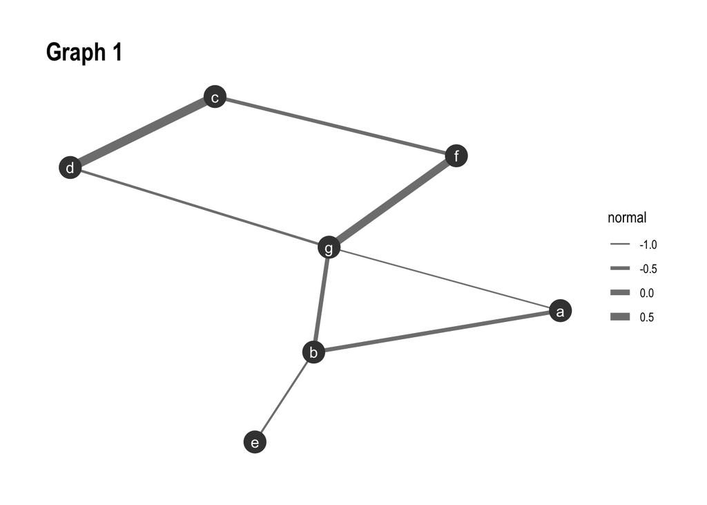

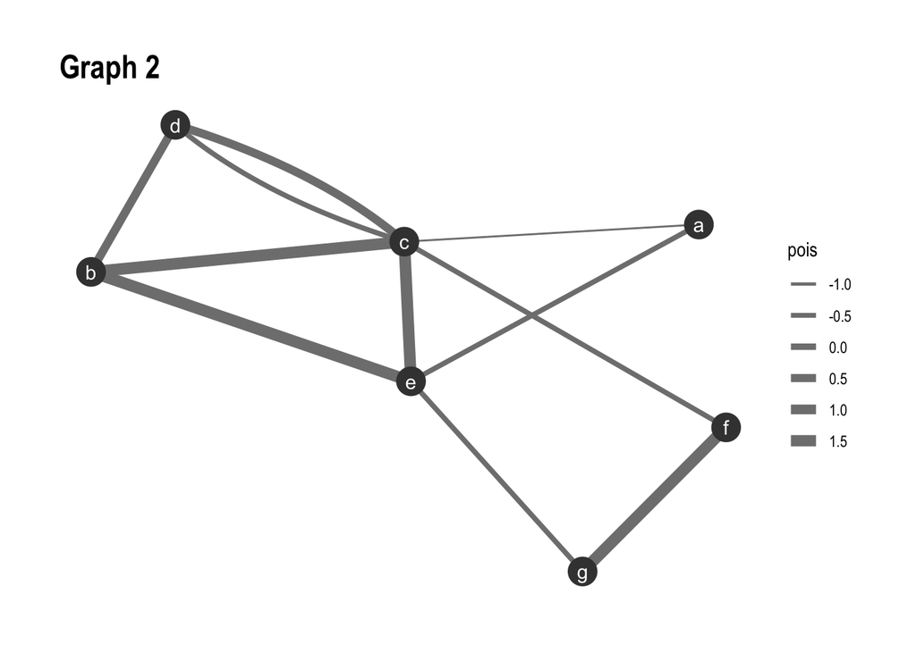

```r
el1 <- expand.grid(letters[1:7], letters[1:7], stringsAsFactors = FALSE) %>%
    as_tibble() %>%
    dplyr::rename(from = "Var1", to = "Var2") %>%
    mutate(
        normal = rnorm(n()),
        normal = scale(normal),
        normal = normal * rbernoulli(n(), p = 0.25)
    )

el2 <- expand.grid(letters[1:7], letters[1:7], stringsAsFactors = FALSE) %>%
    as_tibble() %>%
    dplyr::rename(from = "Var1", to = "Var2") %>%
    mutate(
        pois = rpois(n(), 1.3),
        pois = scale(pois),
        pois = pois * rbernoulli(n(), p = 0.25)
    )

gr1 <- as_tbl_graph(el1, directed = FALSE)
gr2 <- as_tbl_graph(el2, directed = FALSE)
```

### Step 3) Merge graphs

```r
merged_el <- MergeEdgelists(as.data.frame(el1), as.data.frame(el2))
head(merged_el)
```

```
##   from to normal pois
## 1    a  a      0    0
## 2    a  b      0    0
## 3    a  c      0    0
## 4    a  d      0    0
## 5    a  e      0    0
## 6    a  f      0    0
```

### Step 4) Generate DILS network

```r
dils_edges <- GenerateDilsNetwork(merged_el, subsample = nrow(merged_el), use.cols = 3:4)
```

### Step 5) Convert the DILS edge list into a graph object

```r
dils_el <- dils_edges$dils.edgelist
dils_gr <- as_tbl_graph(dils_el)
dils_gr
```

```
## # A tbl_graph: 7 nodes and 49 edges
## #
## # A directed multigraph with 1 component
## #
## # Node Data: 7 x 1 (active)
##   name
##   <chr>
## 1 a
## 2 b
## 3 c
## 4 d
## 5 e
## 6 f
## # … with 1 more row
## #
## # Edge Data: 49 x 3
##    from    to dils.link.coefficients
##   <int> <int>                  <dbl>
## 1     1     1                      0
## 2     1     2                      0
## 3     1     3                      0
## # … with 46 more rows
```

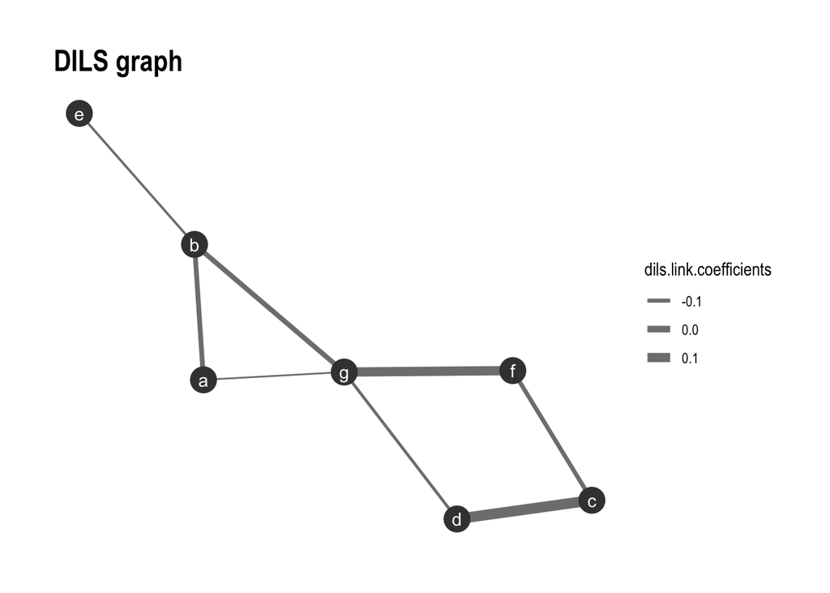

```r
dils_gr %E>%
    filter(dils.link.coefficients != 0) %>%
    ggraph(layout = "nicely") +
    geom_edge_fan(aes(width = dils.link.coefficients), color = "grey50") +
    geom_node_point(size = 7, color = "grey25") +
    geom_node_text(aes(label = name), color = "white") +
    scale_edge_width_continuous(range = c(0.5, 3)) +
    theme_graph() +
    labs(title = "DILS graph")
```

### Step 6) Compare DILS and original graphs

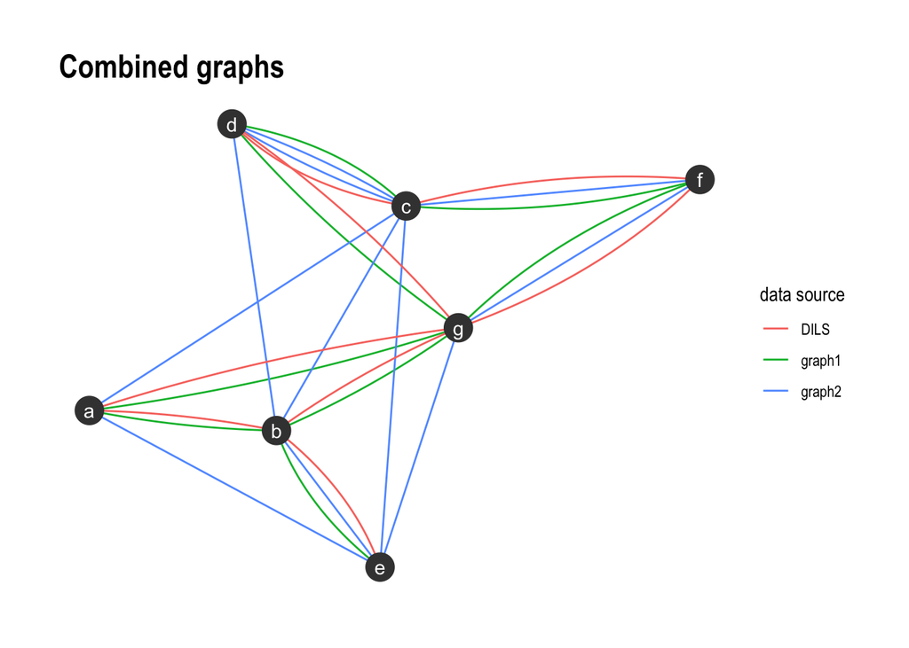

```r
el1$edge_grp <- "graph1"
el2$edge_grp <- "graph2"
dils_el$edge_grp <- "DILS"
el_bind <- bind_rows(el1, el2, dils_el)
as_tbl_graph(el_bind, directed = FALSE) %E>%
    filter(normal != 0 | pois != 0 | dils.link.coefficients | 0) %>%
    ggraph(layout = "nicely") +
    geom_edge_fan(aes(color = edge_grp)) +
    geom_node_point(size = 7, color = "grey25") +
    geom_node_text(aes(label = name), color = "white") +
    theme_graph() +
    labs(edge_color = "data source", title = "Combined graphs")
```